# Disaster Relief Project: Part I

## 3.3 LDA

```r
# calculate predictions for specific fold
lda.cross_val <- function(kfold) {
  lda.fit <- lda(Class.cl~Red+Green+Blue, data = data.kfold, subset=fold!=kfold)
  holdout <- filter(data.kfold, fold == kfold)
  predictions <- lda.fit %>% predict(holdout, type='response')
  # return actual, then predictions
  # Predictions here are a little more complicated than in logistic regression.
  # We needed to specify the second column of posterior predictions.
  return(data_frame(fold=i,actual=holdout$Class.cl,
                    prediction=predictions$posterior[,2],
                    pred_class=predictions$class, x=predictions$x))
}

# perform cross validation by looping through all folds and combining predictions
lda.pred <- data_frame(fold=numeric(),actual=factor(),prediction=numeric(),
                       pred_class=factor(), x=numeric())
for (i in 1:10) {
  lda.pred<-full_join(lda.pred, lda.cross_val(i))
}
```

```r
# https://yardstick.tidymodels.org/reference/roc_curve.html
# calculate ROC
# we need to specify that we are predicting the second variable
lda.roc <- lda.pred %>% roc_curve(actual,prediction, event_level='second')
lda.roc
```

```
#> # A tibble: 49,464 x 3
#>     .threshold specificity sensitivity
#>          <dbl>       <dbl>       <dbl>
#>  1 -Inf          0                   1
#>  2    1.92e-16   0                   1
#>  3    5.02e-16   0.0000163           1
#>  4    4.42e-15   0.0000327           1
#>  5    1.24e-14   0.0000490           1
#>  6    1.50e-14   0.0000653           1
#>  7    1.85e-14   0.0000817           1
#>  8    2.01e-14   0.0000980           1
#>  9    2.18e-14   0.000114            1
#> 10    2.51e-14   0.000131            1
#> # … with 49,454 more rows
```

```r
lda.auc <- lda.pred %>% roc_auc(actual,prediction, event_level='second')
lda.auc
```

```
#> # A tibble: 1 x 3
#>   .metric .estimator .estimate
#>   <chr>   <chr>          <dbl>
#> 1 roc_auc binary         0.989
```

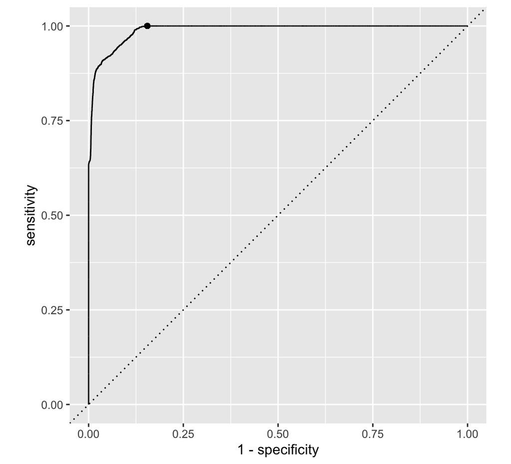

```r
# calculate ideal threshold from ROC
lda.roc <- lda.roc %>% rowid_to_column()
lda.thresh <- lda.roc %>% filter(sensitivity == 1) %>%
  arrange(desc(specificity)) %>% head(1)

# plot ROC
lda.roc %>% ggplot(aes(x = 1 - specificity, y = sensitivity)) +
  geom_path() + geom_abline(lty=3) + coord_equal() +
  geom_point(aes(1-lda.thresh$specificity,lda.thresh$sensitivity))
```

```r
# calculate PR
lda.pr <- lda.pred %>% pr_curve(actual,prediction, event_level='second')
lda.pr
```

```
#> # A tibble: 49,463 x 3
#>    .threshold   recall precision
#>         <dbl>    <dbl>     <dbl>
#>  1     Inf    0                1
#>  2       1.00 0.000495         1
#>  3       1.00 0.000989         1
#>  4       1.00 0.00148          1
#>  5       1.00 0.00198          1
#>  6       1.00 0.00247          1
#>  7       1.00 0.00297          1
#>  8       1.00 0.00346          1
#>  9       1.00 0.00396          1
#> 10       1.00 0.00445          1
#> # … with 49,453 more rows
```

```r
lda.pr_auc <- lda.pred %>% pr_auc(actual,prediction, event_level='second')
lda.pr_auc
```

```
#> # A tibble: 1 x 3
#>   .metric .estimator .estimate
#>   <chr>   <chr>          <dbl>
#> 1 pr_auc  binary         0.859
```

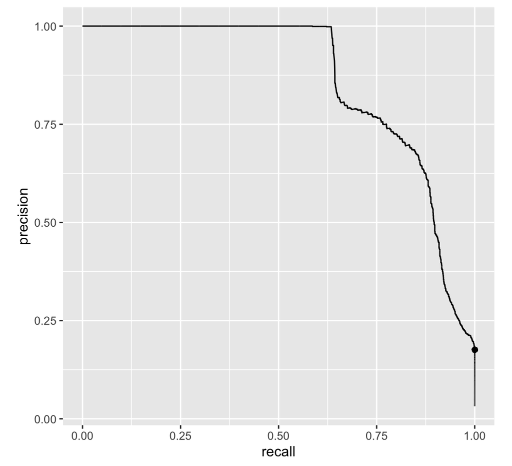

```r
# calculate ideal threshold from PR
lda.pr <- lda.pr %>% rowid_to_column()
lda.thresh.pr <- lda.pr %>% filter(recall == 1) %>%
  arrange(desc(precision)) %>%head(1)

# plot PR
lda.pr %>% ggplot(aes(x = recall, y = precision)) +
  geom_path() + coord_equal() +
  geom_point(aes(lda.thresh.pr$recall,lda.thresh.pr$precision))
```

LDA follows logistic regression model calculation very closely. The only major difference being the lda function is used instead of glm, which leads to a different output format from lda.prediction. However, with minor adjustment the outcome is the same.

The ROC curve is not as strong on LDA as it is on Logistic regression and the precision recall curve shows a sharp drop off in performance. Because we are concerned with the small number of true values in the data, we will weight the precision recall curve more heavily.

## 3.4 QDA

```r
# calculate predictions for current fold
qda.cross_val <- function(kfold) {
  qda.fit <- qda(Class.cl~Red+Green+Blue, data = data.kfold, subset=fold!=kfold)
  holdout <- filter(data.kfold, fold == kfold)
  predictions <- qda.fit %>% predict(holdout, type='response')
  # return actual, then predictions
  # data returned from predictions is similar to LDA
  return(data_frame(fold=i,actual=holdout$Class.cl,
                    prediction=predictions$posterior[,2]))
}

# perform cross validation and gather predictions across folds
qda.pred <- data_frame(fold=numeric(),actual=factor(),prediction=numeric())
for (i in 1:10) {
  qda.pred<-full_join(qda.pred, qda.cross_val(i))
}
```

```r
# https://yardstick.tidymodels.org/reference/roc_curve.html
# calculate ROC
qda.roc <- qda.pred %>% roc_curve(actual,prediction, event_level='second')
qda.roc
```

```
#> # A tibble: 49,464 x 3
#>     .threshold specificity sensitivity
#>          <dbl>       <dbl>       <dbl>
#>  1 -Inf          0                   1
#>  2    8.05e-33   0                   1
#>  3    3.63e-31   0.0000163           1
#>  4    5.81e-30   0.0000327           1
#>  5    3.02e-29   0.0000490           1
#>  6    1.87e-28   0.0000653           1
#>  7    6.71e-28   0.0000817           1
#>  8    9.91e-28   0.0000980           1
#>  9    1.54e-27   0.000114            1
#> 10    1.03e-26   0.000131            1
#> # … with 49,454 more rows
```

```r
qda.auc <- qda.pred %>% roc_auc(actual,prediction, event_level='second')
qda.auc
```

```
#> # A tibble: 1 x 3
#>   .metric .estimator .estimate
#>   <chr>   <chr>          <dbl>
#> 1 roc_auc binary         0.998
```

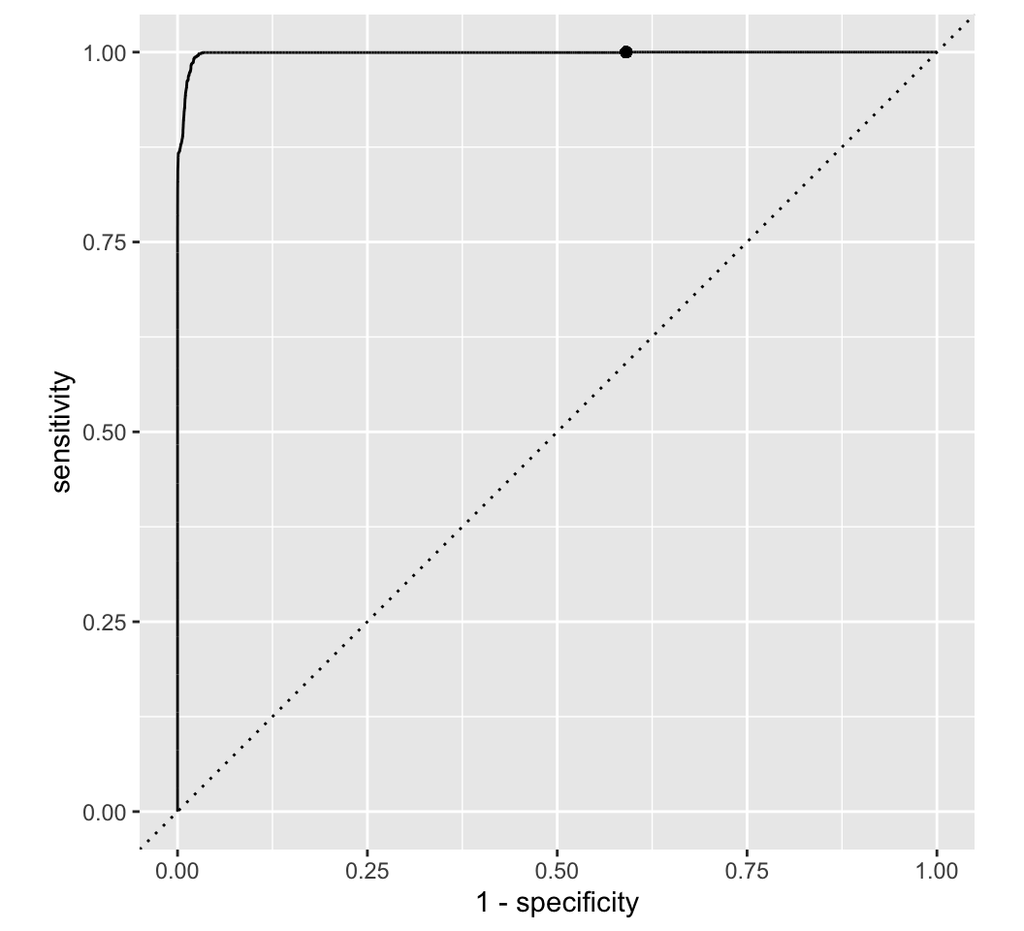

```r
# calculate ideal threshold from ROC
qda.roc <- qda.roc %>% rowid_to_column()
qda.thresh <- qda.roc %>% filter(sensitivity == 1) %>%
  arrange(desc(specificity)) %>% head(1)

# plot ROC
qda.roc %>% ggplot(aes(x = 1 - specificity, y = sensitivity)) +
  geom_path() + geom_abline(lty=3) + coord_equal() +
  geom_point(aes(1-qda.thresh$specificity,qda.thresh$sensitivity))
```

```r
# calculate PR
qda.pr <- qda.pred %>% pr_curve(actual,prediction, event_level='second')
qda.pr
```

```
#> # A tibble: 49,463 x 3
#>    .threshold   recall precision
#>         <dbl>    <dbl>     <dbl>
#>  1     Inf    0                1
#>  2       1.00 0.000495         1
#>  3       1.00 0.000989         1
#>  4       1.00 0.00148          1
#>  5       1.00 0.00198          1
#>  6       1.00 0.00247          1
#>  7       1.00 0.00297          1
#>  8       1.00 0.00346          1
#>  9       1.00 0.00396          1
#> 10       1.00 0.00445          1
#> # … with 49,453 more rows
```

```r
qda.pr_auc <- qda.pred %>% pr_auc(actual,prediction, event_level='second')
qda.pr_auc
```

```
#> # A tibble: 1 x 3
#>   .metric .estimator .estimate
#>   <chr>   <chr>          <dbl>
#> 1 pr_auc  binary         0.965
```

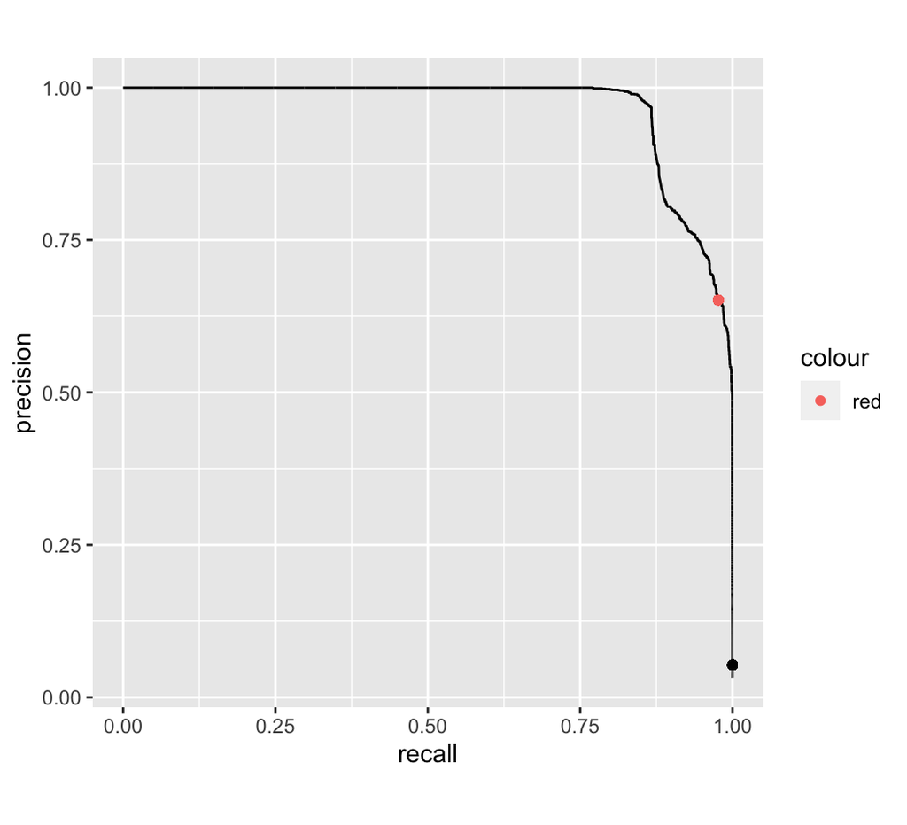

```r
# calculate ideal threshold from PR
qda.pr <- qda.pr %>% rowid_to_column()
qda.thresh.pr <- qda.pr %>% filter(recall == 1) %>%
  arrange(desc(precision)) %>% head(1)
qda.thresh.pr.hp <- qda.pr[2600,]

# plot PR
qda.pr %>% ggplot(aes(x = recall, y = precision)) +
  geom_path() + coord_equal() +
  geom_point(aes(qda.thresh.pr$recall,qda.thresh.pr$precision)) +
  geom_point(aes(qda.pr[2600,]$recall,qda.pr[2600,]$precision, colour = 'red'))
```

One major difference with the precision recal curve is that the process I used to select the ideal threshold gives us a value with very small precision. I also selected another point in red that appeared to be better positioned. This point was hand picked by selecting a point that appear to be in an ideal position visually.

## 3.5 KNN

```r
# use my 10 folds for use in caret::train:
# https://stackoverflow.com/questions/48458407/cross-validation-predictions-from-caret-in-assigned-to-different-folds
getFoldList <- function(i){
  fold <- data.kfold %>% filter(fold==i)
  fold$rowid
}
fold_list <- 1:10 %>% purrr::map(getFoldList)

# fit model
ctl <- trainControl(method = "cv", index = fold_list) #, savePredictions = 'final', classProbs=TRUE) not saving predictions
knn.fit <- caret::train(Class.cl~Red+Green+Blue, data = data.kfold,
                        method = 'knn', trControl = ctl)
knn.fit
```

```
#> k-Nearest Neighbors
#>
#> 63241 samples
#>     3 predictor
#>     2 classes: 'Other', 'Blue Tarp'
#>
#> No pre-processing
#> Resampling: Cross-Validated (10 fold)
#> Summary of sample sizes: 6323, 6325, 6324, 6324, 6324, 6324, ...
#> Resampling results across tuning parameters:
#>
#>   k  Accuracy   Kappa
#>   5  0.9961611  0.9377746
#>   7  0.9959502  0.9342853
#>   9  0.9958431  0.9324288
#>
#> Accuracy was used to select the optimal model using the largest value.
#> The final value used for the model was k = 5.
```

```r
knn.fit$bestTune
```

```
#>   k
#> 1 5
```

```r
knn.fit$finalModel
```

```
#> 5-nearest neighbor model
#> Training set outcome distribution:
#>
#>     Other Blue Tarp
#>     61219      2022
```

```r
# create a function for calculating predictions based on the final model parameters, given a fold
knn.cross_val <- function(kfold) {
  ctl.none <- trainControl(method = "none") # relying on this post https://stats.stackexchange.com/questions/23763/is-there-a-way-to-disable-the-parameter-tuning-grid-feature-in-caret
  knn.fit.tuned <- caret::train(Class.cl~Red+Green+Blue, data = data.kfold,
                        subset=fold!=kfold, method = 'knn', trControl = ctl.none,
                        tuneGrid = knn.fit$bestTune)
  holdout <- filter(data.kfold, fold == kfold)
  predictions <- knn.fit.tuned %>% predict(holdout, 'prob')
  # return actual, then predictions
  # data returned from predictions is similar to LDA
  return(data_frame(fold=i,actual=holdout$Class.cl,
                    prediction=1-predictions$BlueTarp))
}

# calculate predictions on data using best model
knn.pred <- data_frame(fold=numeric(),actual=factor(),prediction=numeric())
for (i in 1:10) {
  knn.pred<-full_join(knn.pred, knn.cross_val(i))
}
```

[output not shown]

```r
# calculate ROC
knn.roc <- knn.pred %>% roc_curve(actual,prediction)
```

[output not shown]

```r
knn.roc
```

```
#> Error in eval(expr, envir, enclos): object 'knn.roc' not found
```

```r
knn.auc <- knn.pred %>% roc_auc(actual,prediction)
```

[output not shown]

```r
knn.auc
```

```
#> Error in eval(expr, envir, enclos): object 'knn.auc' not found
```

```r
# calculate ideal threshold from ROC
knn.roc <- knn.roc %>% rowid_to_column()
```

```
#> Error in rowid_to_column(.): object 'knn.roc' not found
```

```r
knn.thresh <- knn.roc %>% filter(sensitivity == 1) %>%
  arrange(desc(specificity)) %>% head(1)
```

[output not shown]

```r
# plot ROC
knn.roc %>% ggplot(aes(x = 1 - specificity, y = sensitivity)) +
  geom_path() + geom_abline(lty=3) + coord_equal() +
  geom_point(aes(1-knn.thresh$specificity,knn.thresh$sensitivity))
```

```
#> Error in ggplot(., aes(x = 1 - specificity, y = sensitivity)): object 'knn.roc' not found
```

```r
# calculate PR
knn.pr <- knn.pred %>% pr_curve(actual,prediction) # use caret package to get optimal tuning parameter, (k=5), new function for the folds
knn.pr
```

```
#> # A tibble: 1 x 3
#>   .threshold recall precision
#>        <dbl>  <dbl>     <dbl>
#> 1        Inf      0         1
```

```r
knn.pr_auc <- knn.pred %>% pr_auc(actual,prediction)
knn.pr_auc
```

```
#> # A tibble: 1 x 3
#>   .metric .estimator .estimate
#>   <chr>   <chr>          <dbl>
#> 1 pr_auc  binary             0
```

```r
# calculate ideal threshold from PR
knn.pr <- knn.pr %>% rowid_to_column()
knn.thresh.pr <- knn.pr %>% filter(recall == 1) %>%
  arrange(desc(precision)) %>% head(1)

# plot PR
knn.pr %>% ggplot(aes(x = recall, y = precision)) +
  geom_path() + coord_equal() +
  scale_y_continuous(expand = c(0, 0), limits = c(.00,1.05)) +
  geom_point(aes(knn.thresh.pr$recall,knn.thresh.pr$precision))
```

```
#> Error: Aesthetics must be either length 1 or the same as the data (1): x and y
```

### 3.5.1 Tuning Parameter $k$

```r
knn.fit$finalModel
```

```
#> 5-nearest neighbor model
#> Training set outcome distribution:
#>
#>     Other Blue Tarp
#>     61219      2022
```

```r
knn.fit$bestTune
```

```
#>   k
#> 1 5
```

```r
knn.fit$results
```

```
#>   k  Accuracy     Kappa   AccuracySD     KappaSD
#> 1 5 0.9961611 0.9377746 0.0002210399 0.004020758
#> 2 7 0.9959502 0.9342853 0.0002664929 0.004729823
#> 3 9 0.9958431 0.9324288 0.0003148741 0.005395091
```

The Caret package will run the cross validation through multiple values of k to select the optimal model. The best model is the final model shown above, with the best tune of k=5. This is the model we used to calculate the ROC curve and precision recall curve. You can see from the table that this model had the best accuracy, though it is not clear the threshold used to determine that accuracy, or if this is another measure of accuracy.

## 3.6 Penalized Logistic Regression (ElasticNet)

```r
# First method
# loop through lambda and alpha
library(glmnet)
set.seed(42)

# https://stackoverflow.com/questions/48280074/r-how-to-let-glmnet-select-lambda-while-providing-an-alpha-range-in-caret
elnet.fit <- caret::train(Class.cl~Red+Green+Blue, data=data.kfold,
                        method="glmnet", trControl=trainControl("cv",
                        returnResamp='all', index = fold_list, search = "grid"))  # !!!!!!!!!!!!!! check these, why return resample....
```

```r
# create a function for calculating predictions based on the final model parameters, given a fold
elnet.cross_val <- function(kfold) {
  ctl.none <- trainControl(method = "none") # relying on this post https://stats.stackexchange.com/questions/23763/is-there-a-way-to-disable-the-parameter-tuning-grid-feature-in-caret
  elnet.fit.tuned <- caret::train(Class.cl~Red+Green+Blue, data=data.kfold, subset=fold!=kfold,
                        method="glmnet", trControl=ctl.none, tuneGrid=elnet.fit$bestTune)
  holdout <- filter(data.kfold, fold == kfold)
  predictions <- elnet.fit.tuned %>% predict(holdout, 'prob')
  # return actual, then predictions
  # data returned from predictions is similar to LDA
  return(data_frame(fold=i,actual=holdout$Class.cl,
                    prediction=1-predictions$BlueTarp))
}

# calculate predictions on data using best model
elnet.pred <- data_frame(fold=numeric(),actual=factor(),prediction=numeric())
for (i in 1:10) {
  elnet.pred<-full_join(elnet.pred, elnet.cross_val(i))
}
```

[output not shown]

```r
# calculate ROC
elnet.roc <- elnet.pred %>% roc_curve(actual,prediction)
```

[output not shown]

```r
elnet.roc
```

```
#> Error in eval(expr, envir, enclos): object 'elnet.roc' not found
```

```r
elnet.auc <- elnet.pred %>% roc_auc(actual,prediction)
```

[output not shown]

```r
elnet.auc
```

```
#> Error in eval(expr, envir, enclos): object 'elnet.auc' not found
```

```r
# calculate ideal threshold from ROC
elnet.roc <- elnet.roc %>% rowid_to_column()
```

```
#> Error in rowid_to_column(.): object 'elnet.roc' not found
```

```r
elnet.thresh <- elnet.roc %>% filter(sensitivity == 1) %>%
  arrange(desc(specificity)) %>% head(1)
```

[output not shown]

```r
# plot ROC
elnet.roc %>% ggplot(aes(x = 1 - specificity, y = sensitivity)) +
  geom_path() + geom_abline(lty=3) + coord_equal() +
  scale_y_continuous(expand = c(0, 0), limits = c(.00,1.05)) +
  geom_point(aes(1-elnet.thresh$specificity,elnet.thresh$sensitivity))
```

```
#> Error in ggplot(., aes(x = 1 - specificity, y = sensitivity)): object 'elnet.roc' not found
```

```r
# calculate PR
elnet.pr <- elnet.pred %>% pr_curve(actual,prediction)
elnet.pr
```

```
#> # A tibble: 1 x 3
#>   .threshold recall precision
#>        <dbl>  <dbl>     <dbl>
#> 1        Inf      0         1
```

```r
elnet.pr_auc <- elnet.pred %>% pr_auc(actual,prediction)
elnet.pr_auc
```

```
#> # A tibble: 1 x 3
#>   .metric .estimator .estimate
#>   <chr>   <chr>          <dbl>
#> 1 pr_auc  binary             0
```

```r
# calculate ideal threshold from PR
elnet.pr <- elnet.pr %>% rowid_to_column()
elnet.thresh.pr <- elnet.pr %>% filter(recall == 1) %>%
  arrange(desc(precision)) %>% head(1)
elnet.thresh.pr.hp <- elnet.pr[1900,]
```

```r
# plot PR
elnet.pr %>% ggplot(aes(x = recall, y = precision)) +
  geom_path() + coord_equal() +
  scale_y_continuous(expand = c(0, 0), limits = c(.00,1.05)) +
  geom_point(aes(elnet.thresh.pr$recall,elnet.thresh.pr$precision)) +
  geom_point(aes(elnet.pr[1900,]$recall,
                 elnet.pr[1900,]$precision, colour = 'red'))
```

```
#> Error: Aesthetics must be either length 1 or the same as the data (1): x and y
```

### 3.6.1 Tuning Parameters

```r
elnet.fit$finalModel %>% tidy() %>% head(10)
```

```
#> # A tibble: 10 x 5
#>    term         step estimate lambda dev.ratio
#>    <chr>       <dbl>    <dbl>  <dbl>     <dbl>
#>  1 (Intercept)     1    -3.41 0.0416 -1.69e-13
#>  2 (Intercept)     2    -3.66 0.0379  3.34e- 2
#>  3 (Intercept)     3    -3.90 0.0345  6.11e- 2
#>  4 (Intercept)     4    -4.13 0.0315  8.46e- 2
#>  5 (Intercept)     5    -4.35 0.0287  1.05e- 1
#>  6 (Intercept)     6    -4.57 0.0261  1.22e- 1
#>  7 (Intercept)     7    -4.79 0.0238  1.37e- 1
#>  8 (Intercept)     8    -5.00 0.0217  1.50e- 1
#>  9 (Intercept)     9    -5.21 0.0198  1.61e- 1
#> 10 (Intercept)    10    -5.41 0.0180  1.71e- 1
```

```r
elnet.fit$bestTune
```

```
#>   alpha       lambda
#> 7     1 8.322155e-05
```

```r
elnet.fit$results
```

```
#>   alpha       lambda  Accuracy      Kappa   AccuracySD     KappaSD
#> 1  0.10 8.322155e-05 0.9935871 0.88582329 0.0004607613 0.009039671
#> 2  0.10 8.322155e-04 0.9873816 0.74791964 0.0008907367 0.020106389
#> 3  0.10 8.322155e-03 0.9686473 0.03658366 0.0008569820 0.035498941
#> 4  0.55 8.322155e-05 0.9941933 0.89820710 0.0004230630 0.008167783
#> 5  0.55 8.322155e-04 0.9893933 0.79578944 0.0008342802 0.017931401
#> 6  0.55 8.322155e-03 0.9706678 0.14606151 0.0017632151 0.078172744
#> 7  1.00 8.322155e-05 0.9950823 0.91620831 0.0002582712 0.005095955
#> 8  1.00 8.322155e-04 0.9931953 0.87765099 0.0005212525 0.010316629
#> 9  1.00 8.322155e-03 0.9803029 0.54542429 0.0017897003 0.054553473
```

```r
elnet.fit$coefnames
```

```
#> [1] "Red"   "Green" "Blue"
```

Elastic net has two tuning parameters, alpha and lambda. Alpha controls the type of impact from the penalty, while lambda controls the strength of the penalty. After attempting for a while to create my own tuning grid, I discovered a way to get the caret package to find the optimal alpha and lambda on it’s own. My assumption is that the ideal lambda is set using accuracy of the predictions, however, I know that this was done without passing in the threshold I have selected so there is probably room for optimizing these tuning parameters.

The end result was that an alpha of 1 was selected with a lambda of 8.322155e-05, row 7 under results. Compared to the other lambdas and alphas considered, this one has the highest accuracy. An alpha of 1 indicates that this model behaves like lasso penalized regression, suggesting that a model could be eliminated, but looking up coefficient names, it appears that all three colors were kept.

**NOTE: PART II same as above plus add Random Forest and SVM to Model Training.**